# Robinhood App Reviews

## 5. Sentiment

Another interesting aspect of text analysis can be the sentiment of written text. In the next exercise I will check the sentiment of the reviews using different packages, including basic libraries AFINN, Bing et al., NRC and the financial words package Loughran and McDonald.

### 5.1 Sentiment during time

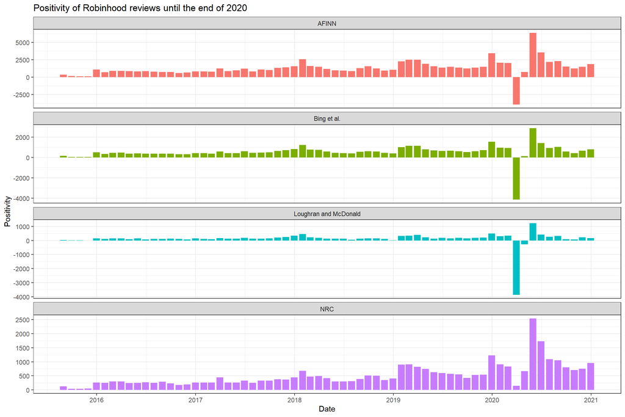

```r
# Check Sentiment ------------------------------------------------

afinn <- tidy_df %>%
  inner_join(get_sentiments('afinn')) %>%
  group_by(month_end) %>%
  summarise(sentiment = sum(value)) %>%
  mutate(method = 'AFINN')

bing_nrc_and_loughran <- bind_rows(tidy_df %>%
                                     inner_join(get_sentiments("bing")) %>%
                                     mutate(method = "Bing et al."),
                                     tidy_df %>%
                                     inner_join(get_sentiments("nrc") %>%
                                                  filter(sentiment %in% c("positive",
                                                                          "negative"))) %>%
                                     mutate(method = "NRC"),
                                     tidy_df %>%
                                     inner_join(get_sentiments("loughran") %>%
                                                  filter(sentiment %in% c("positive",
                                                                          "negative"))) %>%
                                     mutate(method = "Loughran and McDonald")) %>%
  count(method, month_end, sentiment) %>%
  spread(sentiment,n,fill=0) %>%
  mutate(sentiment=positive-negative)


bind_rows(filter(afinn, month_end<'2021-01-01'),
          filter(bing_nrc_and_loughran, month_end<'2021-01-01')) %>%
  ggplot(aes(month_end,sentiment,fill=method))+
  geom_col(show.legend = FALSE)+
  facet_wrap(~method, ncol=1, scales="free_y") +
  scale_x_date(date_labels="%Y",date_breaks  ="1 year") +
  labs(title="Positivity of Robinhood reviews until the end of 2020", x="Date", y="Positivity") +
  theme_bw()
```

However if we are looking at their whole carrier, including the year 2021 we can see how extreme the reviews went because of the GameStop events. The sentiment hit an extreme negativity regardless which sentiment package are we considering.

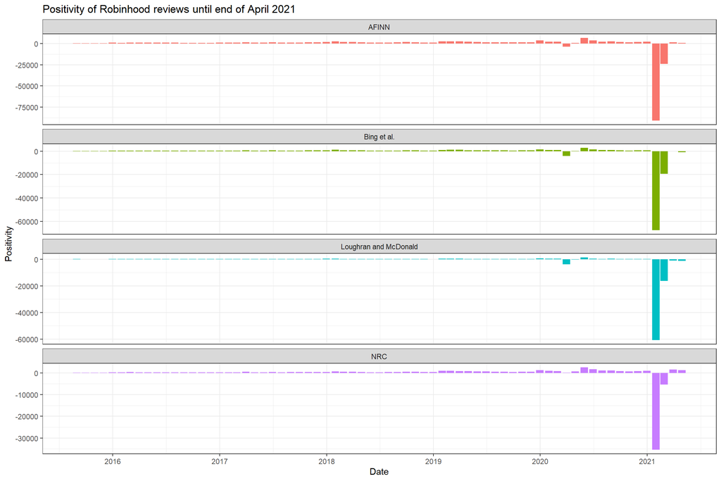

```r
bind_rows(afinn,
          bing_nrc_and_loughran) %>%
  ggplot(aes(month_end,sentiment,fill=method))+
  geom_col(show.legend = FALSE)+
  facet_wrap(~method, ncol=1, scales="free_y") +
  scale_x_date(date_labels="%Y",date_breaks  ="1 year") +
  labs(title="Positivity of Robinhood reviews until end of April 2021", x="Date", y="Positivity") +
  theme_bw()
```

### 5.2 Loughran and McDonald words

The most effective sentiment package in our case is probably the Loughran and McDonald, which can take into account the positivity of financial words. Below we can see the top10 words in each category of the Loughran and McDonald package taking into account the whole timeline of Robinhood.

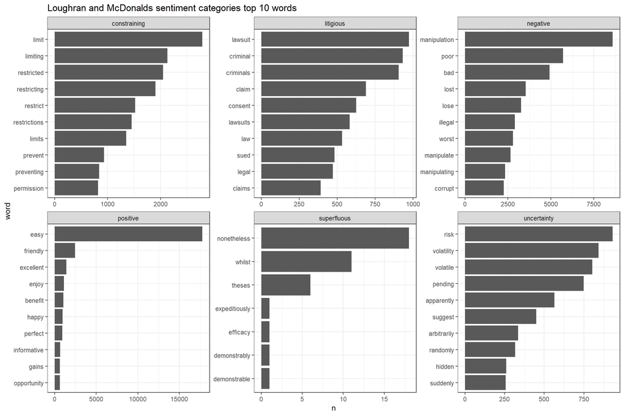

```r
# Loughran words ----------------------------------------------------------

loughran_words <- tidy_df %>%
  count(word, sort=TRUE) %>%
  inner_join(get_sentiments('loughran')) %>%
  group_by(sentiment) %>%
  top_n(10, n) %>%
  ungroup() %>%
  mutate(word = reorder(word,n))

ggplot(loughran_words, aes(x=word, y=n)) +
  geom_col() +
  coord_flip() +
  facet_wrap(~ sentiment, scales = 'free') +
  labs(title="Loughran and McDonalds sentiment categories top 10 words") +
  theme_bw()
```

If we have a look at the changing of positivity across time according to the Loughran and McDonald package, we can spot that the shape is very similar to what we have seen at the beginning on the monthly ratings chart.

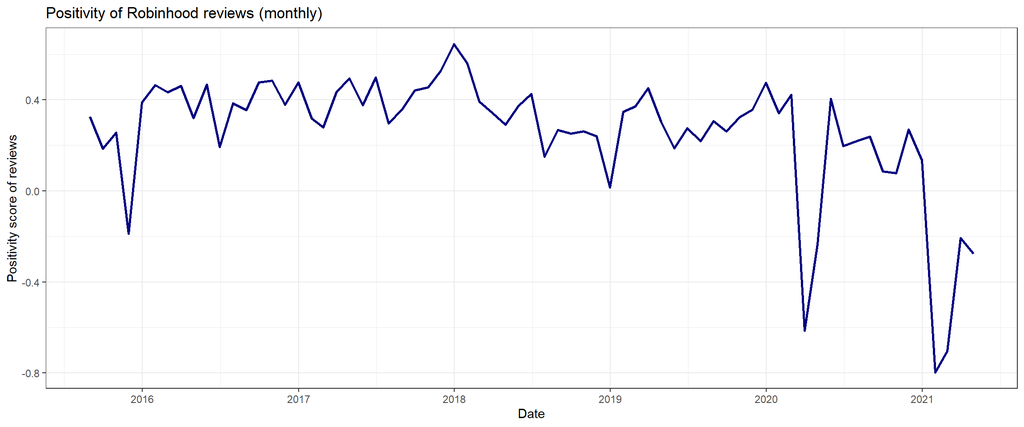

```r
# Positivity according to Loughran and McDonald sentiment during time

loughran_period <- tidy_df %>%
  inner_join(get_sentiments('loughran')) %>%
  count(sentiment, period) %>%
  spread(sentiment, n, fill = 0)

loughran_date <- tidy_df %>%
  inner_join(get_sentiments('loughran')) %>%
  count(sentiment, month_end) %>%
  spread(sentiment, n, fill = 0)

loughran_date %>%
  mutate(score = (positive-negative) / (positive + negative)) %>%
  ggplot(aes(x=month_end, y=score)) +
  geom_line(color='navyblue', size=1) +
  scale_x_date(date_labels="%Y",date_breaks  ="1 year") +
  labs(title='Positivity of Robinhood reviews (monthly)', x='Date', y='Positivity score of reviews') +
  theme_bw()
```

## 6. Topic modelling

Finally let’s have a look at topic modeling. From the written reviews my goal is to create a 2 clusters topic analysis. Hopefully the results will tell us whether based on the words of a user we can predict whether the review was written before or after the Gamestop events. So using the topicmodel package LDA function I created a 2 topics clustering. Below we can see what were the 15 most important words by topic. We can already notice for the first look that there are many common words in the two topics according to LDA.

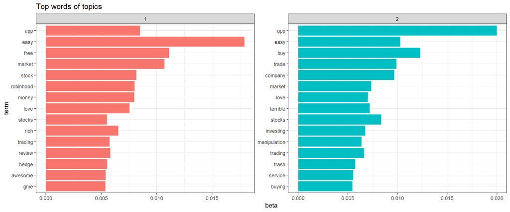

```r
tf_idf_id <- tidy_df %>%
  count(id, period, word, sort = T) %>%
  ungroup() %>%
  bind_tf_idf(word,id,n) %>%
  arrange(desc(tf_idf))

tf_idf_filtered <- tf_idf_id %>% filter(tf_idf > median(tf_idf_id$tf_idf))

tf_idf_dtm <- tf_idf_filtered %>%
  unite(document, period, id) %>%
  count(document, word) %>%
  cast_dtm(document, word, n)

tf_idf_lda <- LDA(tf_idf_dtm, k = 2, control = list(seed = 20210523))

tf_idf_lda %>% tidy(matrix="beta") %>%
  group_by(topic) %>%
  top_n(15, beta) %>%
  ungroup() %>%
  arrange(topic, -beta) %>%
  mutate(term = reorder(term,beta)) %>%
  ggplot(aes(term,beta,fill = factor(topic)))+geom_col(show.legend = F) +
  facet_wrap(~topic, scales = 'free') +
  coord_flip() +
  labs(title="Top words of topics") +
  theme_bw()
```

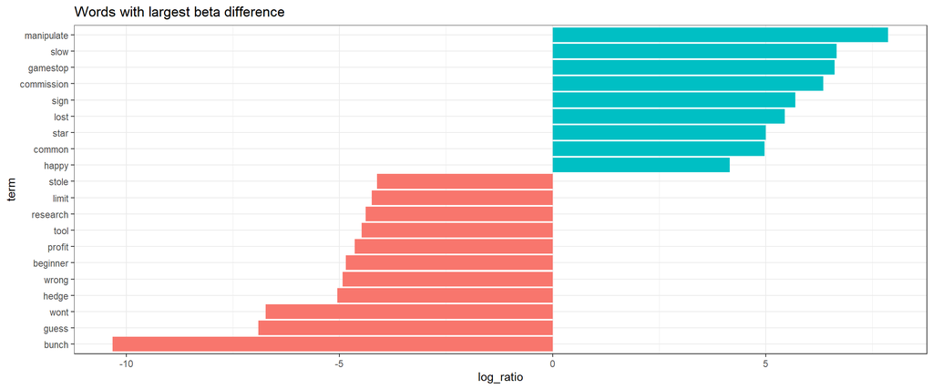

```r
tf_idf_lda %>% tidy(matrix="beta") %>%
  mutate(topic = paste0("topic", topic)) %>%
  spread(topic, beta) %>%
  filter(topic1 > .001 | topic2 > .001) %>%
  mutate(log_ratio = log2(topic2 / topic1)) %>%
  top_n(20,abs(log_ratio)) %>%
  mutate(term = reorder(term,log_ratio) ) %>%
  ggplot(aes(term, log_ratio, fill = log_ratio > 0)) +
  geom_col(show.legend = FALSE) +
  coord_flip() +
  labs(title="Words with largest beta difference") +
  theme_bw()
```

Finally, looking at the boxplots we can see that we cannot pair the two topics to the Robinhood periods. So using only the vocabulary of reviews is not enough by itself to help us identify whether a review was written before or after the 28th of January. A possible explanation to this can be what we have seen already on the ratings chart. After the GameStop event the number of positive reviews started to increase again in March and April, so probably the attitude against the company will come back to normal after some time passes similarly to what happened after the drop of sentiment in case of the server outages in 2020. As a result the positive words appear after the scandal as well and it makes topic segmentation harder for us.

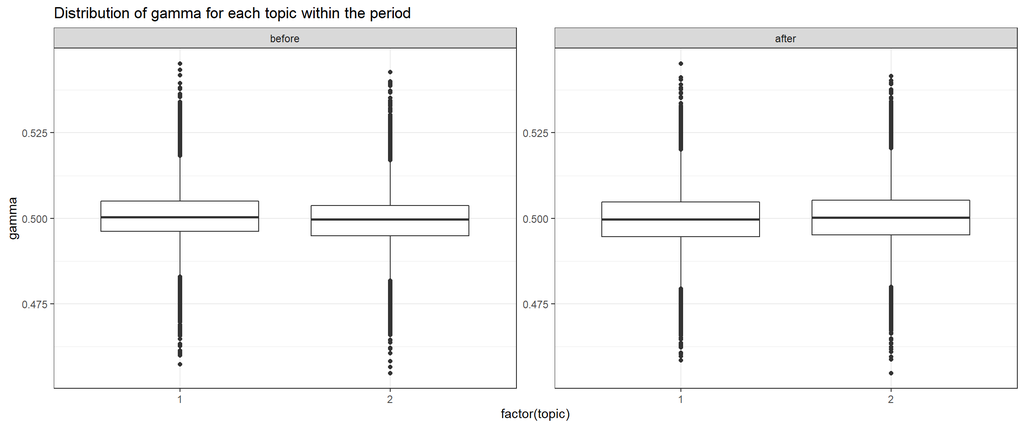

```r
tf_idf_lda %>%
  tidy(matrix = 'gamma') %>%
  separate(document, c('period', 'id'), sep = '_') %>%
  mutate(top_critic = reorder(period, gamma * topic)) %>%
  ggplot(aes(factor(topic), gamma)) +
  geom_boxplot() +
  facet_wrap(~factor(period,levels=c('before','after')), scales = 'free') +
  labs(title="Distribution of gamma for each topic within the period") +
  theme_bw()
```

## 7. Conclusion

In this project I tried to show how the sentiment changed against Robinhood due to the story of GameStop. To achieve my goal, I used several R packages capable of natural text analysis. I found interesting relationship in the words used before and after the 28th of January, also we were able to see that after the GME event happened, tons of negativity flooded their Google Play Store review section. The sentiment of the reviews have also confirmed what the word frequencies told us and all the 4 sentiment packages marked an extreme value of negativity in the review section. Finally, we had a look at topic modeling whether it can tell a review was written before or after the GME scandal without knowing the date of the review. Although, it turned out that we cannot distinguish the two period by only taking into account the vocabulary, it can still bring us an interesting conclusion. There is a possibility that after some time passes the attitude against the company will return to its normal state similarly to the past.